# Group Project: Research Question 1b

Saadana Balasubramanian

2026-07-26

# Research Question 1b

This section of the code addresses the second component of the first research question: “What is the prevalence of subjective sleep disturbance and what are its predictors in post liver transplant recipients?”

Each sleep quality score was modelled using demographic variables (Age, Gender, BMI, time elapsed since transplant, liver diagnosis, recurrence of disease, evidence of rejection/graft dysfunction, any fibrosis, renal failure, depression, and corticosteroid use) as predictors.

## Chosen Models

The four instruments were recorded on different scales so two modeling strategies were used depending on the instrument:

1. **Continuous outcome — multiple linear regression.** PSQI, ESS, and AIS are all instruments that use numeric scores to indicate sleep quality. A multiple linear regression model was used to predict sleep quality while all demographic variables were entered as predictors. The output shows the estimated association of each predictor with sleep score while holding all other predictors constant.
2. **Binary outcome — multiple logistic regression.** BSS uses a binary scale (1 = disturbance present). Additionally, PSQI, ESS, and AIS measurements were also converted to binary variables, using the clinically accepted thresholds to ensure the analysis is comprehensive. Multiple logistic regression models with the same set of predictors was used for these scales.

## Model Fitting and Comparison

There are 3 linear and 4 logistic models that were fitted on `predictor_data`. This cleaned dataset contains all 11 predictors.

The coefficient (or odds ratio for logistic models), 95% confidence interval, and p-value per predictor is derived from each model. From this, a summary table of p-values across all 7 models is constructed to compare which predictors are significant in each model.

# R Code

## Load Packages & Import Data

```r
# Packages used in this script -------------------------------------------
# car   : vif() for multicollinearity diagnostics
# knitr : kable() for formatted tables in the knitted report

library(car)
library(knitr)

#The existing cleaning pipeline is converted into an .R script
knitr::purl("group_project.Rmd", output = "group_project_cleaning.R", quiet = TRUE)
```

```
## [1] "group_project_cleaning.R"
```

```r
source("group_project_cleaning.R")
```

```
## 'data.frame':    268 obs. of  94 variables:
##  $ Subject                                  : int  1 2 3 4 5 6 7 8 9 10 ...
##  $ Gender                                   : int  1 1 1 1 1 1 1 2 2 2 ...
##  $ Age                                      : int  62 54 50 45 57 56 39 55 48 55 ...
##  $ Employment                               : int  1 7 1 1 8 1 1 6 6 7 ...
##  $ Marital.Status                           : int  5 1 3 4 3 3 3 3 3 3 ...
##  $ Education                                : int  4 NA 4 3 3 4 4 4 4 4 ...
##  $ Height                                   : num  1.78 1.69 1.74 NA 1.69 1.73 1.78 1.55 1.68 1.57 ...
##  $ weight                                   : num  74.2 73.6 53 70 71.3 ...
##  $ BMI                                      : num  23.4 25.8 26.8 NA 25 ...
##  $ Children                                 : int  3 3 3 2 3 0 1 0 0 0 ...
##  $ Dependents.living.at.home                : int  0 0 3 0 0 0 1 1 0 0 ...
##  $ Ethnicity                                : int  2 4 4 4 4 4 4 4 4 4 ...
##  $ Household.income                         : int  2 1 2 2 2 3 3 NA 3 2 ...
##  $ Date.of.transplant                       : chr  "01-Mar" "08-Mar" "03-Jun" "Jul-91" ...
```

[output cut: 80 more lines]

```r
# Confirm the objects we need now exist before continuing
stopifnot(exists("sleep_data"), exists("predictor_data"))
dim(predictor_data)
```

```
## [1] 243  20
```

## Missing data check

Using lm() and glm() automatically drops missing values and conducts a complete-case analysis by default. Before fitting the models, this initial check is to find where missing data occurs. If there was a large number of measured variables (ie. age, BMI, depression) that are missing for certain outcomes then this would suggest those values are missing not at random (NMAR). In this case, the sample isn’t representative of the population and complete-case analysis would be biased.

```r
# sapply() is used to apply the same function across every column in the list
# this is used to count how many NA values are in each column

sapply(predictor_data[, c("PSQI", "ESS", "AIS", "PSQI_quality", "ESS_disturbance", "AIS_insomnia", "BSS", "age", "gender", "BMI", "transplant_time", "liver_diagnosis", "recurrence", "graft_dysfunction", "fibrosis", "renal_failure","depression", "corticosteroid")],
       function(x) sum(is.na(x)))
```

```
##              PSQI               ESS               AIS      PSQI_quality
##                80                15                 5                 0
##   ESS_disturbance      AIS_insomnia               BSS               age
##                 0                 0                 6                 0
##            gender               BMI   transplant_time   liver_diagnosis
##                 0                 0                 0                 0
##        recurrence graft_dysfunction          fibrosis     renal_failure
##                 0                 0                 0                 0
##        depression    corticosteroid
##                 0                 0
```

```r
# Check is PSQI missing data > 30%
n_total <- nrow(predictor_data)

psqi_missing_pct <- sum(is.na(predictor_data$PSQI)) / n_total * 100
round(psqi_missing_pct, 1)
```

```
## [1] 32.9
```

```r
psqi_missing_pct
```

```
## [1] 32.92181
```

**Findings**: The table shows that there are no missing values for any of the predictors which suggests that complete-case analysis is appropriate to use. However, there are missing values for the outcome variables (PSQI:80;ESS:15;AIS:5; BSS:6).

## Linear Regression Models (continuous variables)

All 11 predictors are entered simultaneously in each model. Each coefficient represents the effect of that predictor while holding the others constant.

```r
# lm() fits a multiple linear regression model.

lm_PSQI <- lm(PSQI ~ age + gender + BMI + transplant_time + liver_diagnosis +
recurrence + graft_dysfunction + fibrosis + renal_failure + depression +
corticosteroid, data = predictor_data)

lm_ESS <- lm(ESS ~ age + gender + BMI + transplant_time + liver_diagnosis +
recurrence + graft_dysfunction + fibrosis + renal_failure + depression +
corticosteroid, data = predictor_data)

lm_AIS <- lm(AIS ~ age + gender + BMI + transplant_time + liver_diagnosis +
recurrence + graft_dysfunction + fibrosis + renal_failure + depression +
corticosteroid, data = predictor_data)

# The estimated beta coefficients, p-value and standard error for each model
summary(lm_PSQI)
```

```
##
## Call:
## lm(formula = PSQI ~ age + gender + BMI + transplant_time + liver_diagnosis +
##     recurrence + graft_dysfunction + fibrosis + renal_failure +
##     depression + corticosteroid, data = predictor_data)
##
## Residuals:
##     Min      1Q  Median      3Q     Max
## -7.6990 -3.5014 -0.7197  2.4380 11.8284
##
## Coefficients:
##                             Estimate Std. Error t value Pr(>|t|)
## (Intercept)                 6.036368   2.634686   2.291   0.0234 *
## age                        -0.040215   0.030939  -1.300   0.1957
## genderFemale                1.211397   0.831968   1.456   0.1475
## BMI                         0.089027   0.069712   1.277   0.2036
## transplant_time            -0.068497   0.078063  -0.877   0.3817
## liver_diagnosisHep B       -0.429862   1.493266  -0.288   0.7739
## liver_diagnosisPSC/PBC/AHA  0.005009   1.285235   0.004   0.9969
## liver_diagnosisalcohol     -0.243790   1.549116  -0.157   0.8752
## liver_diagnosisother        0.422582   1.263657   0.334   0.7385
## recurrenceYes               2.088226   1.211009   1.724   0.0867 .
## graft_dysfunctionYes       -2.474729   1.052149  -2.352   0.0200 *
## fibrosisYes                 2.147687   1.470539   1.460   0.1463
## renal_failureYes           -0.591281   2.424896  -0.244   0.8077
## depressionYes               1.747683   0.921071   1.897   0.0597 .
## corticosteroidYes           2.012555   0.917638   2.193   0.0299 *
## ---
## Signif. codes:  0 '***' 0.001 '**' 0.01 '*' 0.05 '.' 0.1 ' ' 1
##
## Residual standard error: 4.582 on 148 degrees of freedom
##   (80 observations deleted due to missingness)
## Multiple R-squared:  0.1812, Adjusted R-squared:  0.1037
## F-statistic: 2.339 on 14 and 148 DF,  p-value: 0.005997
```

```r
summary(lm_ESS)
```

```
##
## Call:
## lm(formula = ESS ~ age + gender + BMI + transplant_time + liver_diagnosis +
##     recurrence + graft_dysfunction + fibrosis + renal_failure +
##     depression + corticosteroid, data = predictor_data)
##
## Residuals:
##     Min      1Q  Median      3Q     Max
## -8.4958 -3.3532 -0.6264  3.0751 11.7704
##
## Coefficients:
##                            Estimate Std. Error t value Pr(>|t|)
## (Intercept)                 8.42790    2.12688   3.963 0.000101 ***
## age                        -0.02256    0.02647  -0.852 0.395028
## genderFemale               -0.75140    0.68319  -1.100 0.272645
## BMI                         0.04514    0.05593   0.807 0.420495
## transplant_time             0.02387    0.06295   0.379 0.704965
## liver_diagnosisHep B       -0.77184    1.25884  -0.613 0.540439
## liver_diagnosisPSC/PBC/AHA -2.47608    1.02167  -2.424 0.016205 *
## liver_diagnosisalcohol     -1.68940    1.21179  -1.394 0.164729
## liver_diagnosisother       -2.12391    1.03740  -2.047 0.041851 *
## recurrenceYes              -0.82922    0.97778  -0.848 0.397357
## graft_dysfunctionYes        1.62451    0.88857   1.828 0.068914 .
## fibrosisYes                 0.24078    1.15456   0.209 0.834998
## renal_failureYes           -1.68239    2.31540  -0.727 0.468264
## depressionYes               0.93676    0.75548   1.240 0.216354
## corticosteroidYes           1.51567    0.71263   2.127 0.034581 *
## ---
## Signif. codes:  0 '***' 0.001 '**' 0.01 '*' 0.05 '.' 0.1 ' ' 1
##
## Residual standard error: 4.472 on 213 degrees of freedom
##   (15 observations deleted due to missingness)
## Multiple R-squared:  0.1148, Adjusted R-squared:  0.05659
## F-statistic: 1.973 on 14 and 213 DF,  p-value: 0.02114
```

```r
summary(lm_AIS)
```

```
##
## Call:
## lm(formula = AIS ~ age + gender + BMI + transplant_time + liver_diagnosis +
##     recurrence + graft_dysfunction + fibrosis + renal_failure +
##     depression + corticosteroid, data = predictor_data)
##
## Residuals:
##     Min      1Q  Median      3Q     Max
## -9.7548 -3.8654 -0.9826  2.6460 17.5991
##
## Coefficients:
##                            Estimate Std. Error t value Pr(>|t|)
## (Intercept)                 7.82074    2.37921   3.287  0.00118 **
## age                        -0.06427    0.02962  -2.170  0.03110 *
## genderFemale                0.45164    0.77417   0.583  0.56023
## BMI                         0.07490    0.06259   1.197  0.23268
## transplant_time            -0.11584    0.07111  -1.629  0.10469
## liver_diagnosisHep B       -0.82802    1.36084  -0.608  0.54350
## liver_diagnosisPSC/PBC/AHA  0.54160    1.16318   0.466  0.64194
## liver_diagnosisalcohol      0.23390    1.36569   0.171  0.86417
## liver_diagnosisother        0.36319    1.15803   0.314  0.75410
## recurrenceYes               2.45072    1.09317   2.242  0.02596 *
## graft_dysfunctionYes       -0.69156    0.98647  -0.701  0.48401
## fibrosisYes                 1.39369    1.29372   1.077  0.28252
## renal_failureYes           -0.76785    2.64643  -0.290  0.77197
## depressionYes               0.93854    0.85458   1.098  0.27328
## corticosteroidYes           1.91808    0.80108   2.394  0.01748 *
## ---
## Signif. codes:  0 '***' 0.001 '**' 0.01 '*' 0.05 '.' 0.1 ' ' 1
##
## Residual standard error: 5.116 on 223 degrees of freedom
##   (5 observations deleted due to missingness)
## Multiple R-squared:  0.1476, Adjusted R-squared:  0.09403
## F-statistic: 2.757 on 14 and 223 DF,  p-value: 0.0008658
```

```r
# 95% confidence intervals for the linear regression model coefficients,
# rounded to 2 decimal places.
round(confint(lm_PSQI), 2)
```

```
##                            2.5 % 97.5 %
## (Intercept)                 0.83  11.24
## age                        -0.10   0.02
## genderFemale               -0.43   2.86
## BMI                        -0.05   0.23
## transplant_time            -0.22   0.09
## liver_diagnosisHep B       -3.38   2.52
## liver_diagnosisPSC/PBC/AHA -2.53   2.54
## liver_diagnosisalcohol     -3.31   2.82
## liver_diagnosisother       -2.07   2.92
## recurrenceYes              -0.30   4.48
## graft_dysfunctionYes       -4.55  -0.40
## fibrosisYes                -0.76   5.05
## renal_failureYes           -5.38   4.20
## depressionYes              -0.07   3.57
## corticosteroidYes           0.20   3.83
```

```r
round(confint(lm_ESS), 2)
```

```
##                            2.5 % 97.5 %
## (Intercept)                 4.24  12.62
## age                        -0.07   0.03
## genderFemale               -2.10   0.60
## BMI                        -0.07   0.16
## transplant_time            -0.10   0.15
## liver_diagnosisHep B       -3.25   1.71
## liver_diagnosisPSC/PBC/AHA -4.49  -0.46
## liver_diagnosisalcohol     -4.08   0.70
## liver_diagnosisother       -4.17  -0.08
## recurrenceYes              -2.76   1.10
## graft_dysfunctionYes       -0.13   3.38
## fibrosisYes                -2.04   2.52
## renal_failureYes           -6.25   2.88
## depressionYes              -0.55   2.43
## corticosteroidYes           0.11   2.92
```

```r
round(confint(lm_AIS), 2)
```

```
##                            2.5 % 97.5 %
## (Intercept)                 3.13  12.51
## age                        -0.12  -0.01
## genderFemale               -1.07   1.98
## BMI                        -0.05   0.20
## transplant_time            -0.26   0.02
## liver_diagnosisHep B       -3.51   1.85
## liver_diagnosisPSC/PBC/AHA -1.75   2.83
## liver_diagnosisalcohol     -2.46   2.93
## liver_diagnosisother       -1.92   2.65
## recurrenceYes               0.30   4.60
## graft_dysfunctionYes       -2.64   1.25
## fibrosisYes                -1.16   3.94
## renal_failureYes           -5.98   4.45
## depressionYes              -0.75   2.62
## corticosteroidYes           0.34   3.50
```

## Diagnostics and Multiple Comparisons

The assumptions of linear regression models are based on equal variance of residuals, normality of residuals and linearity. These conditions must be met to ensure that the model’s predictions are accurate. Diagnostic plots were used to evaluate if these assumptions have been met. The models were also checked for multicollinearity using the variance inflation factor (VIF). The multicollinearity check confirms the assumption that none of the predictors in the models are correlated with each other.

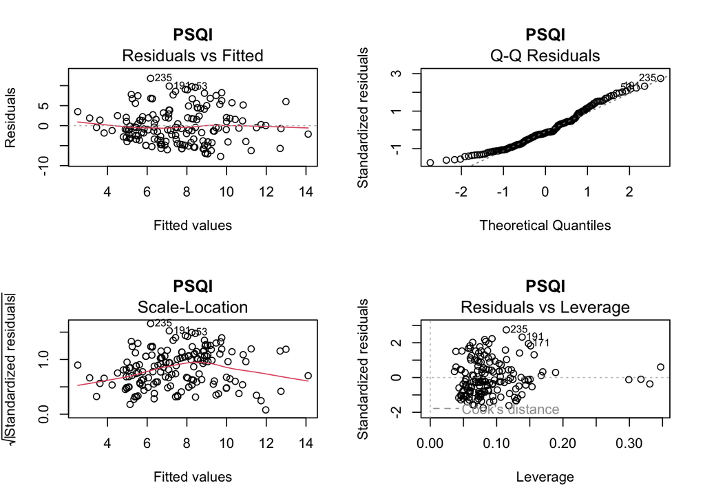

```r
# Residual diagnostic plots
par(mfrow = c(2, 2))
plot(lm_PSQI, main = "PSQI")
```

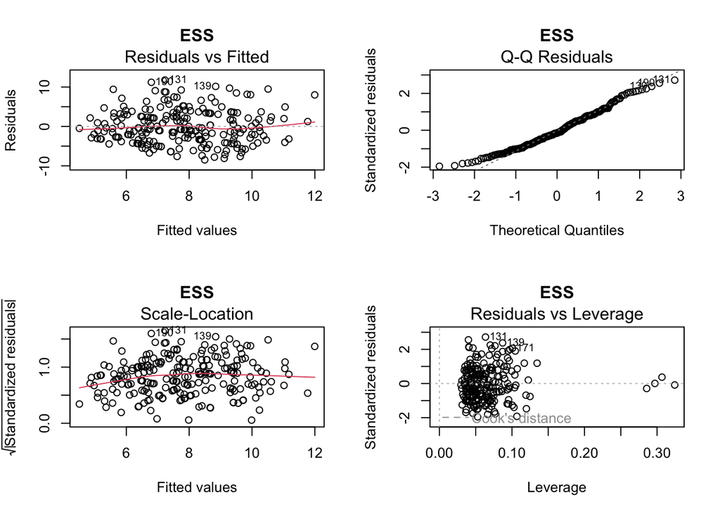

```r
plot(lm_ESS,  main = "ESS")
```

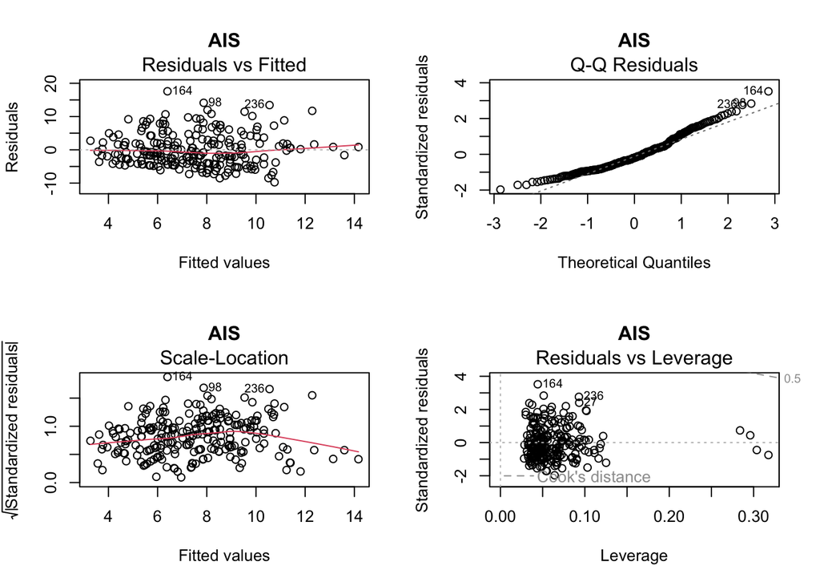

```r
plot(lm_AIS,  main = "AIS")
```

```r
par(mfrow = c(1, 1))

# Multicollinearity check - VIF > 5 (or 10) flags problematic predictors
vif(lm_PSQI)
```

```
##                       GVIF Df GVIF^(1/(2*Df))
## age               1.195528  1        1.093402
## gender            1.266590  1        1.125429
## BMI               1.165016  1        1.079359
## transplant_time   1.222586  1        1.105706
## liver_diagnosis   2.964043  4        1.145475
## recurrence        2.072483  1        1.439612
## graft_dysfunction 1.669223  1        1.291984
## fibrosis          2.108090  1        1.451926
## renal_failure     1.092831  1        1.045386
## depression        1.133449  1        1.064636
## corticosteroid    1.324332  1        1.150796
```

```r
vif(lm_ESS)
```

```
##                       GVIF Df GVIF^(1/(2*Df))
## age               1.285731  1        1.133901
## gender            1.225294  1        1.106930
## BMI               1.104430  1        1.050918
## transplant_time   1.194801  1        1.093069
## liver_diagnosis   2.790767  4        1.136882
## recurrence        2.090299  1        1.445787
## graft_dysfunction 1.763667  1        1.328031
## fibrosis          2.154482  1        1.467815
## renal_failure     1.053281  1        1.026295
## depression        1.129714  1        1.062880
## corticosteroid    1.231582  1        1.109766
```

```r
vif(lm_AIS)
```

```
##                       GVIF Df GVIF^(1/(2*Df))
## age               1.269768  1        1.126840
## gender            1.237727  1        1.112532
## BMI               1.099152  1        1.048404
## transplant_time   1.198678  1        1.094842
## liver_diagnosis   2.812833  4        1.138002
## recurrence        2.048729  1        1.431338
## graft_dysfunction 1.704560  1        1.305588
## fibrosis          2.041873  1        1.428941
## renal_failure     1.052287  1        1.025810
## depression        1.133859  1        1.064828
## corticosteroid    1.221415  1        1.105176
```

**Reasoning:** Using plot on a lm() creates 4 diagnostic plots. par(mfrow = c(2, 2)) arranges these plots in a 2x2 grid. The first plot checks linearity by ensuring that points are randomly scattered around the horizontal line at 0. A curved pattern in this plot would indicate that there is a non-linear relationship. The second qq plot checks whether residuals are normally distributed by ensuring that points fall along a diagonal line. Since the sample size is large (150-260 per model), the data is expected to be normally distributed. The third plot checks for equal variance of residuals by ensuring that points are spread horizontally. The fourth plot checks if there are certain observations that disproportionately affect the model.

**Findings:**

*Multicollinearity check:* There were no VIF scores above 5, which confirms that none of the predictors in the model are correlated with each other.

## Logistic Regression Models (Binary Sleep Outcomes)

All 11 predictors are entered simultaneously in each model. Each coefficient represents the effect of that predictor while holding the others constant.

```r
# glm(..., family = binomial) fits a multiple logistic regression.
# Coefficients represent the log-odds of success
# exponentiate = TRUE converts log-odds to odds ratios

glm_PSQI_full <- glm(PSQI_quality ~ age + gender + BMI + transplant_time +
liver_diagnosis + recurrence + graft_dysfunction + fibrosis + renal_failure +
depression + corticosteroid, data = predictor_data, family = binomial)

glm_ESS_full <- glm(ESS_disturbance ~ age + gender + BMI + transplant_time + liver_diagnosis + recurrence + graft_dysfunction + fibrosis + renal_failure +
depression + corticosteroid, data = predictor_data, family = binomial)

glm_AIS_full <- glm(AIS_insomnia ~ age + gender + BMI + transplant_time +
liver_diagnosis + recurrence + graft_dysfunction + fibrosis + renal_failure +
depression + corticosteroid, data = predictor_data, family = binomial)

glm_BSS_full <- glm(BSS ~ age + gender + BMI + transplant_time +
liver_diagnosis + recurrence + graft_dysfunction + fibrosis + renal_failure +
depression + corticosteroid, data = predictor_data, family = binomial)

# The estimated beta coefficients, p-value and standard error for each model
summary(glm_PSQI_full)
```

```
##
## Call:
## glm(formula = PSQI_quality ~ age + gender + BMI + transplant_time +
##     liver_diagnosis + recurrence + graft_dysfunction + fibrosis +
##     renal_failure + depression + corticosteroid, family = binomial,
##     data = predictor_data)
##
## Coefficients:
##                             Estimate Std. Error z value Pr(>|z|)
## (Intercept)                -1.422117   0.995489  -1.429  0.15313
## age                        -0.009496   0.011961  -0.794  0.42723
## genderFemale               -0.029136   0.313197  -0.093  0.92588
## BMI                         0.020767   0.025900   0.802  0.42267
## transplant_time            -0.005240   0.028838  -0.182  0.85580
## liver_diagnosisHep B        0.850968   0.570991   1.490  0.13614
## liver_diagnosisPSC/PBC/AHA  1.650141   0.514016   3.210  0.00133 **
## liver_diagnosisalcohol      0.776869   0.594783   1.306  0.19151
## liver_diagnosisother        1.537907   0.508427   3.025  0.00249 **
## recurrenceYes               0.969687   0.477073   2.033  0.04210 *
## graft_dysfunctionYes        0.078939   0.410864   0.192  0.84764
## fibrosisYes                -0.090234   0.533931  -0.169  0.86580
## renal_failureYes            0.657475   1.124652   0.585  0.55881
## depressionYes               0.602942   0.355178   1.698  0.08959 .
## corticosteroidYes          -0.725914   0.339417  -2.139  0.03246 *
## ---
## Signif. codes:  0 '***' 0.001 '**' 0.01 '*' 0.05 '.' 0.1 ' ' 1
##
## (Dispersion parameter for binomial family taken to be 1)
##
##     Null deviance: 332.90  on 242  degrees of freedom
## Residual deviance: 308.61  on 228  degrees of freedom
## AIC: 338.61
##
## Number of Fisher Scoring iterations: 4
```

```r
summary(glm_ESS_full)
```

```
##
## Call:
## glm(formula = ESS_disturbance ~ age + gender + BMI + transplant_time +
##     liver_diagnosis + recurrence + graft_dysfunction + fibrosis +
##     renal_failure + depression + corticosteroid, family = binomial,
##     data = predictor_data)
##
## Coefficients:
##                              Estimate Std. Error z value Pr(>|z|)
## (Intercept)                 -0.890427   1.106248  -0.805   0.4209
## age                         -0.005234   0.014397  -0.364   0.7162
## genderFemale                -0.262682   0.369887  -0.710   0.4776
## BMI                          0.013476   0.028207   0.478   0.6328
## transplant_time             -0.004643   0.033913  -0.137   0.8911
## liver_diagnosisHep B        -0.878217   0.662709  -1.325   0.1851
## liver_diagnosisPSC/PBC/AHA  -1.365610   0.550226  -2.482   0.0131 *
## liver_diagnosisalcohol      -0.778241   0.635677  -1.224   0.2209
## liver_diagnosisother        -0.673084   0.524616  -1.283   0.1995
## recurrenceYes                0.008066   0.488180   0.017   0.9868
## graft_dysfunctionYes         0.630134   0.434878   1.449   0.1473
## fibrosisYes                 -0.174458   0.550175  -0.317   0.7512
## renal_failureYes           -14.890857 718.598463  -0.021   0.9835
## depressionYes                0.520853   0.371103   1.404   0.1605
## corticosteroidYes            0.777010   0.367423   2.115   0.0345 *
## ---
## Signif. codes:  0 '***' 0.001 '**' 0.01 '*' 0.05 '.' 0.1 ' ' 1
##
## (Dispersion parameter for binomial family taken to be 1)
##
##     Null deviance: 278.13  on 242  degrees of freedom
## Residual deviance: 252.90  on 228  degrees of freedom
## AIC: 282.9
##
## Number of Fisher Scoring iterations: 14
```

```r
summary(glm_AIS_full)
```

```
##
## Call:
## glm(formula = AIS_insomnia ~ age + gender + BMI + transplant_time +
##     liver_diagnosis + recurrence + graft_dysfunction + fibrosis +
##     renal_failure + depression + corticosteroid, family = binomial,
##     data = predictor_data)
##
## Coefficients:
##                             Estimate Std. Error z value Pr(>|z|)
## (Intercept)                 0.182478   1.013864   0.180   0.8572
## age                        -0.013950   0.012157  -1.147   0.2512
## genderFemale               -0.089362   0.314870  -0.284   0.7766
## BMI                         0.007151   0.026874   0.266   0.7902
## transplant_time            -0.034420   0.029039  -1.185   0.2359
## liver_diagnosisHep B        0.212715   0.537894   0.395   0.6925
## liver_diagnosisPSC/PBC/AHA  0.535458   0.486622   1.100   0.2712
## liver_diagnosisalcohol     -0.457899   0.584151  -0.784   0.4331
## liver_diagnosisother        0.742914   0.484224   1.534   0.1250
## recurrenceYes               0.963050   0.464677   2.073   0.0382 *
## graft_dysfunctionYes       -0.481816   0.418000  -1.153   0.2490
## fibrosisYes                 0.363724   0.538726   0.675   0.4996
## renal_failureYes            1.021337   1.235724   0.827   0.4085
## depressionYes               0.924505   0.377794   2.447   0.0144 *
## corticosteroidYes           0.399764   0.335022   1.193   0.2328
## ---
## Signif. codes:  0 '***' 0.001 '**' 0.01 '*' 0.05 '.' 0.1 ' ' 1
##
## (Dispersion parameter for binomial family taken to be 1)
##
##     Null deviance: 335.38  on 242  degrees of freedom
## Residual deviance: 305.48  on 228  degrees of freedom
## AIC: 335.48
##
## Number of Fisher Scoring iterations: 4
```

```r
summary(glm_BSS_full)
```

```
##
## Call:
## glm(formula = BSS ~ age + gender + BMI + transplant_time + liver_diagnosis +
##     recurrence + graft_dysfunction + fibrosis + renal_failure +
##     depression + corticosteroid, family = binomial, data = predictor_data)
##
## Coefficients:
##                             Estimate Std. Error z value Pr(>|z|)
## (Intercept)                 -6.13734    1.20714  -5.084 3.69e-07 ***
## age                          0.01389    0.01359   1.022   0.3068
## genderFemale                -0.11986    0.35540  -0.337   0.7359
## BMI                          0.16548    0.03146   5.260 1.44e-07 ***
## transplant_time              0.02446    0.03178   0.769   0.4416
## liver_diagnosisHep B         0.27841    0.60642   0.459   0.6462
## liver_diagnosisPSC/PBC/AHA   0.36080    0.52597   0.686   0.4927
## liver_diagnosisalcohol      -0.37604    0.63582  -0.591   0.5542
## liver_diagnosisother         0.44305    0.51395   0.862   0.3887
## recurrenceYes                0.88741    0.48821   1.818   0.0691 .
## graft_dysfunctionYes        -0.22145    0.45386  -0.488   0.6256
## fibrosisYes                 -0.43573    0.59136  -0.737   0.4612
## renal_failureYes           -14.76773  707.20959  -0.021   0.9833
## depressionYes                0.07009    0.38690   0.181   0.8562
## corticosteroidYes           -0.12091    0.36904  -0.328   0.7432
## ---
## Signif. codes:  0 '***' 0.001 '**' 0.01 '*' 0.05 '.' 0.1 ' ' 1
##
## (Dispersion parameter for binomial family taken to be 1)
##
##     Null deviance: 313.71  on 236  degrees of freedom
## Residual deviance: 265.50  on 222  degrees of freedom
##   (6 observations deleted due to missingness)
## AIC: 295.5
##
## Number of Fisher Scoring iterations: 14
```

```r
# Odds ratios

# For each logistic model, exponentiating the coefficients converts them from
# log-odds to odds ratios. Values above 1 indicate higher odds of poor sleep
# quality while values below 1 indicate lower odds.
round(exp(glm_PSQI_full$coefficients), 2)
```

```
##                (Intercept)                        age
##                       0.24                       0.99
##               genderFemale                        BMI
##                       0.97                       1.02
##            transplant_time       liver_diagnosisHep B
##                       0.99                       2.34
## liver_diagnosisPSC/PBC/AHA     liver_diagnosisalcohol
##                       5.21                       2.17
##       liver_diagnosisother              recurrenceYes
##                       4.65                       2.64
##       graft_dysfunctionYes                fibrosisYes
##                       1.08                       0.91
##           renal_failureYes              depressionYes
##                       1.93                       1.83
##          corticosteroidYes
##                       0.48
```

```r
round(exp(glm_ESS_full$coefficients), 2)
```

```
##                (Intercept)                        age
##                       0.41                       0.99
##               genderFemale                        BMI
##                       0.77                       1.01
##            transplant_time       liver_diagnosisHep B
##                       1.00                       0.42
## liver_diagnosisPSC/PBC/AHA     liver_diagnosisalcohol
##                       0.26                       0.46
##       liver_diagnosisother              recurrenceYes
##                       0.51                       1.01
##       graft_dysfunctionYes                fibrosisYes
##                       1.88                       0.84
##           renal_failureYes              depressionYes
##                       0.00                       1.68
##          corticosteroidYes
##                       2.17
```

```r
round(exp(glm_AIS_full$coefficients), 2)
```

```
##                (Intercept)                        age
##                       1.20                       0.99
##               genderFemale                        BMI
##                       0.91                       1.01
##            transplant_time       liver_diagnosisHep B
##                       0.97                       1.24
## liver_diagnosisPSC/PBC/AHA     liver_diagnosisalcohol
##                       1.71                       0.63
##       liver_diagnosisother              recurrenceYes
##                       2.10                       2.62
##       graft_dysfunctionYes                fibrosisYes
##                       0.62                       1.44
##           renal_failureYes              depressionYes
##                       2.78                       2.52
##          corticosteroidYes
##                       1.49
```

```r
round(exp(glm_BSS_full$coefficients), 2)
```

```
##                (Intercept)                        age
##                       0.00                       1.01
##               genderFemale                        BMI
##                       0.89                       1.18
##            transplant_time       liver_diagnosisHep B
##                       1.02                       1.32
## liver_diagnosisPSC/PBC/AHA     liver_diagnosisalcohol
##                       1.43                       0.69
##       liver_diagnosisother              recurrenceYes
##                       1.56                       2.43
##       graft_dysfunctionYes                fibrosisYes
##                       0.80                       0.65
##           renal_failureYes              depressionYes
##                       0.00                       1.07
##          corticosteroidYes
##                       0.89
```

```r
# 95% confidence intervals for the odds ratios, rounded to 2 decimal places
round(exp(confint(glm_PSQI_full)), 2)
```

```
##                            2.5 % 97.5 %
## (Intercept)                 0.03   1.67
## age                         0.97   1.01
## genderFemale                0.52   1.79
## BMI                         0.97   1.07
## transplant_time             0.94   1.05
## liver_diagnosisHep B        0.76   7.30
## liver_diagnosisPSC/PBC/AHA  1.96  14.83
## liver_diagnosisalcohol      0.68   7.08
## liver_diagnosisother        1.76  13.09
## recurrenceYes               1.06   6.96
## graft_dysfunctionYes        0.48   2.43
## fibrosisYes                 0.32   2.60
## renal_failureYes            0.18  19.30
## depressionYes               0.91   3.70
## corticosteroidYes           0.24   0.93
```

```r
round(exp(confint(glm_ESS_full)), 2)
```

```
##                            2.5 %       97.5 %
## (Intercept)                 0.05 3.550000e+00
## age                         0.97 1.020000e+00
## genderFemale                0.37 1.570000e+00
## BMI                         0.96 1.070000e+00
## transplant_time             0.93 1.060000e+00
## liver_diagnosisHep B        0.10 1.420000e+00
## liver_diagnosisPSC/PBC/AHA  0.08 7.400000e-01
## liver_diagnosisalcohol      0.12 1.540000e+00
## liver_diagnosisother        0.18 1.420000e+00
## recurrenceYes               0.38 2.590000e+00
## graft_dysfunctionYes        0.79 4.410000e+00
## fibrosisYes                 0.28 2.470000e+00
## renal_failureYes              NA 1.711055e+29
## depressionYes               0.81 3.480000e+00
## corticosteroidYes           1.06 4.500000e+00
```

```r
round(exp(confint(glm_AIS_full)), 2)
```

```
##                            2.5 % 97.5 %
## (Intercept)                 0.16   8.83
## age                         0.96   1.01
## genderFemale                0.49   1.70
## BMI                         0.96   1.06
## transplant_time             0.91   1.02
## liver_diagnosisHep B        0.43   3.59
## liver_diagnosisPSC/PBC/AHA  0.66   4.51
## liver_diagnosisalcohol      0.20   1.97
## liver_diagnosisother        0.82   5.53
## recurrenceYes               1.07   6.70
## graft_dysfunctionYes        0.27   1.39
## fibrosisYes                 0.51   4.24
## renal_failureYes            0.29  61.36
## depressionYes               1.22   5.43
## corticosteroidYes           0.78   2.90
```

```r
round(exp(confint(glm_BSS_full)), 2)
```

```
##                            2.5 %       97.5 %
## (Intercept)                 0.00 2.000000e-02
## age                         0.99 1.040000e+00
## genderFemale                0.44 1.770000e+00
## BMI                         1.11 1.260000e+00
## transplant_time             0.96 1.090000e+00
## liver_diagnosisHep B        0.39 4.320000e+00
## liver_diagnosisPSC/PBC/AHA  0.52 4.090000e+00
## liver_diagnosisalcohol      0.19 2.350000e+00
## liver_diagnosisother        0.57 4.330000e+00
## recurrenceYes               0.95 6.500000e+00
## graft_dysfunctionYes        0.32 1.940000e+00
## fibrosisYes                 0.20 2.040000e+00
## renal_failureYes              NA 5.201546e+28
## depressionYes               0.50 2.280000e+00
## corticosteroidYes           0.43 1.820000e+00
```

## Multicollinearity Check

```r
# Multicollinearity check for the logistic models
vif(glm_PSQI_full)
```

```
##                       GVIF Df GVIF^(1/(2*Df))
## age               1.251038  1        1.118498
## gender            1.213928  1        1.101784
## BMI               1.103459  1        1.050457
## transplant_time   1.199325  1        1.095137
## liver_diagnosis   3.306028  4        1.161217
## recurrence        2.322885  1        1.524102
## graft_dysfunction 1.781581  1        1.334759
## fibrosis          2.134499  1        1.460993
## renal_failure     1.057155  1        1.028180
## depression        1.141556  1        1.068436
## corticosteroid    1.278216  1        1.130582
```

```r
vif(glm_ESS_full)
```

```
##                       GVIF Df GVIF^(1/(2*Df))
## age               1.313028  1        1.145874
## gender            1.191300  1        1.091467
## BMI               1.087897  1        1.043023
## transplant_time   1.182808  1        1.087570
## liver_diagnosis   2.984856  4        1.146477
## recurrence        2.143546  1        1.464085
## graft_dysfunction 1.752442  1        1.323798
## fibrosis          2.113624  1        1.453831
## renal_failure     1.000000  1        1.000000
## depression        1.118600  1        1.057639
## corticosteroid    1.278683  1        1.130789
```

```r
vif(glm_AIS_full)
```

```
##                       GVIF Df GVIF^(1/(2*Df))
## age               1.212405  1        1.101093
## gender            1.203800  1        1.097178
## BMI               1.093936  1        1.045914
## transplant_time   1.196078  1        1.093654
## liver_diagnosis   2.777915  4        1.136226
## recurrence        2.111147  1        1.452979
## graft_dysfunction 1.774892  1        1.332251
## fibrosis          2.067652  1        1.437933
## renal_failure     1.043394  1        1.021466
## depression        1.114392  1        1.055648
## corticosteroid    1.232000  1        1.109955
```

```r
vif(glm_BSS_full)
```

```
##                       GVIF Df GVIF^(1/(2*Df))
## age               1.202985  1        1.096807
## gender            1.229926  1        1.109020
## BMI               1.118965  1        1.057812
## transplant_time   1.189315  1        1.090557
## liver_diagnosis   2.822370  4        1.138484
## recurrence        2.136105  1        1.461542
## graft_dysfunction 1.706395  1        1.306291
## fibrosis          2.035136  1        1.426582
## renal_failure     1.000000  1        1.000000
## depression        1.124735  1        1.060535
## corticosteroid    1.171246  1        1.082241
```

**Findings:**

*Multicollinearity check:* There were no VIF scores above 5 for any of the models, which confirms that none of the predictors in the model are correlated with each other.

## Verifying Maximum Predictors

The maximum number of predictors for each model is identified using the following formula: p =< m/15. The following code identifies the number of sample size in each linear regression model model, and the class with the smallest sample size in each logistic regression model. Then, the maximum number of predictors is found by dividing each sample size by 15 (the generally accepted rule). The final output is displayed as a dataframe.

```r
#nobs() finds the total number of observations that were used to predict the
#output. This identifies the sample size of each linear regression model.
n_PSQI <- nobs(lm_PSQI)
n_ESS <- nobs(lm_ESS)
n_AIS <- nobs(lm_AIS)

#A frequency table is created which contains the number of observations within
#each class of the outcome variable. The class with the smallest sample size
#is used for this calculation. This is identified using 'min' and assigned to
#a new variable.

m_PSQI_glm <- min(table(predictor_data$PSQI_quality))
m_ESS_glm  <- min(table(predictor_data$ESS_disturbance))
m_AIS_glm  <- min(table(predictor_data$AIS_insomnia))
m_BSS_glm  <- min(table(predictor_data$BSS))

#A data frame is created to clearly display results. The first column includes
#the model names. The second column lists the m value of each model and the last
#column shows the maximum number of predictors used.

data.frame(
  model = c("PSQI_lm", "ESS_lm", "AIS_lm",
            "PSQI_quality_glm", "ESS_disturbance_glm", "AIS_insomnia_glm",
            "BSS_glm"),
  m = c(n_PSQI, n_ESS, n_AIS, m_PSQI_glm, m_ESS_glm, m_AIS_glm, m_BSS_glm),
  max_p = floor(c(n_PSQI, n_ESS, n_AIS, m_PSQI_glm, m_ESS_glm, m_AIS_glm,
                  m_BSS_glm) / 15)
)
```

```
##                 model   m max_p
## 1             PSQI_lm 163    10
## 2              ESS_lm 228    15
## 3              AIS_lm 238    15
## 4    PSQI_quality_glm 106     7
## 5 ESS_disturbance_glm  63     4
## 6    AIS_insomnia_glm 112     7
## 7             BSS_glm  89     5
```

**Findings:** Based on this table, the current logistic regression models exceed the maximum number of predictors that can be used (PSQI: 7 max predictors; ESS: 4 max predictors; AIS: 7 max predictors; BSS: 5 max predictors). For these models, there is an increased risk of overfitting and model inaccuracy.

## Secondary analysis with reduced models

Based on the results above, each logistic regression model above exceeds the maximum number of predictors that can be included in each model. To overcome this issue, reduced models were created by narrowing the number of predictors used to avoid exceeding the maximum limit. These predictors were chosen using a priori domain knowledge.

```r
# glm(..., family = binomial) fits a multiple logistic regression.
# Coefficients represent the log-odds of success
# exponentiate = TRUE converts log-odds to odds ratios

# The outcome of each model has been encoded as binary based on the clinically verified thresholds during the data processing procedure.

# PSQI logistic regression with 7 df
glm_PSQI_reduced <- glm(PSQI_quality ~ depression + corticosteroid + BMI +
                          transplant_time + renal_failure + age + gender,
                        family = binomial, data = predictor_data)

# ESS logistic regression with 4 df
glm_ESS_reduced <- glm(ESS_disturbance ~ depression + corticosteroid + BMI +
                         transplant_time,
                       family = binomial, data = predictor_data)

# AIS logistic regression with 7 df
glm_AIS_reduced <- glm(AIS_insomnia ~ depression + corticosteroid + BMI +
                         transplant_time + renal_failure + age + gender,
                       family = binomial, data = predictor_data)

# BSS logistic regression with 5 df
glm_BSS_reduced <- glm(BSS ~ depression + corticosteroid + BMI +
                         transplant_time + age,
                       family = binomial, data = predictor_data)

# The estimated beta coefficients, p-value and standard error for each model
summary(glm_PSQI_reduced)
```

```
##
## Call:
## glm(formula = PSQI_quality ~ depression + corticosteroid + BMI +
##     transplant_time + renal_failure + age + gender, family = binomial,
##     data = predictor_data)
##
## Coefficients:
##                   Estimate Std. Error z value Pr(>|z|)
## (Intercept)       -0.05127    0.86923  -0.059   0.9530
## depressionYes      0.50082    0.33056   1.515   0.1298
## corticosteroidYes -0.43518    0.29948  -1.453   0.1462
## BMI                0.02496    0.02473   1.009   0.3130
## transplant_time    0.01500    0.02672   0.561   0.5745
## renal_failureYes   0.16517    1.04186   0.159   0.8740
## age               -0.01944    0.01123  -1.731   0.0835 .
## genderFemale       0.26320    0.28669   0.918   0.3586
## ---
## Signif. codes:  0 '***' 0.001 '**' 0.01 '*' 0.05 '.' 0.1 ' ' 1
##
## (Dispersion parameter for binomial family taken to be 1)
##
##     Null deviance: 332.90  on 242  degrees of freedom
## Residual deviance: 322.24  on 235  degrees of freedom
## AIC: 338.24
##
## Number of Fisher Scoring iterations: 4
```

```r
summary(glm_ESS_reduced)
```

```
##
## Call:
## glm(formula = ESS_disturbance ~ depression + corticosteroid +
##     BMI + transplant_time, family = binomial, data = predictor_data)
##
## Coefficients:
##                   Estimate Std. Error z value Pr(>|z|)
## (Intercept)       -1.52788    0.76462  -1.998   0.0457 *
## depressionYes      0.62009    0.34573   1.794   0.0729 .
## corticosteroidYes  0.48910    0.31241   1.566   0.1174
## BMI                0.01006    0.02668   0.377   0.7061
## transplant_time   -0.01791    0.03010  -0.595   0.5519
## ---
## Signif. codes:  0 '***' 0.001 '**' 0.01 '*' 0.05 '.' 0.1 ' ' 1
##
## (Dispersion parameter for binomial family taken to be 1)
##
##     Null deviance: 278.13  on 242  degrees of freedom
## Residual deviance: 271.37  on 238  degrees of freedom
## AIC: 281.37
##
## Number of Fisher Scoring iterations: 4
```

```r
summary(glm_AIS_reduced)
```

```
##
## Call:
## glm(formula = AIS_insomnia ~ depression + corticosteroid + BMI +
##     transplant_time + renal_failure + age + gender, family = binomial,
##     data = predictor_data)
##
## Coefficients:
##                    Estimate Std. Error z value Pr(>|z|)
## (Intercept)        0.901427   0.904548   0.997  0.31898
## depressionYes      0.973119   0.356614   2.729  0.00636 **
## corticosteroidYes  0.344901   0.298862   1.154  0.24848
## BMI                0.002002   0.025437   0.079  0.93725
## transplant_time   -0.020225   0.026795  -0.755  0.45037
## renal_failureYes   0.527034   1.204450   0.438  0.66170
## age               -0.018725   0.011380  -1.645  0.09989 .
## genderFemale       0.080304   0.290994   0.276  0.78257
## ---
## Signif. codes:  0 '***' 0.001 '**' 0.01 '*' 0.05 '.' 0.1 ' ' 1
##
## (Dispersion parameter for binomial family taken to be 1)
##
##     Null deviance: 335.38  on 242  degrees of freedom
## Residual deviance: 318.52  on 235  degrees of freedom
## AIC: 334.52
##
## Number of Fisher Scoring iterations: 4
```

```r
summary(glm_BSS_reduced)
```

```
##
## Call:
## glm(formula = BSS ~ depression + corticosteroid + BMI + transplant_time +
##     age, family = binomial, data = predictor_data)
##
## Coefficients:
##                   Estimate Std. Error z value Pr(>|z|)
## (Intercept)       -5.56024    1.06711  -5.211 1.88e-07 ***
## depressionYes      0.04239    0.36315   0.117    0.907
## corticosteroidYes -0.20380    0.33472  -0.609    0.543
## BMI                0.15630    0.02996   5.218 1.81e-07 ***
## transplant_time    0.03055    0.02879   1.061    0.289
## age                0.01192    0.01257   0.948    0.343
## ---
## Signif. codes:  0 '***' 0.001 '**' 0.01 '*' 0.05 '.' 0.1 ' ' 1
##
## (Dispersion parameter for binomial family taken to be 1)
##
##     Null deviance: 313.71  on 236  degrees of freedom
## Residual deviance: 275.39  on 231  degrees of freedom
##   (6 observations deleted due to missingness)
## AIC: 287.39
##
## Number of Fisher Scoring iterations: 4
```

```r
# Odds ratios
# For each logistic model, exponentiating the coefficients converts them from
# log-odds to odds ratios. Values above 1 indicate higher odds of poor sleep
# quality while values below 1 indicate lower odds.

round(exp(glm_PSQI_reduced$coefficients), 2)
```

```
##       (Intercept)     depressionYes corticosteroidYes               BMI
##              0.95              1.65              0.65              1.03
##   transplant_time  renal_failureYes               age      genderFemale
##              1.02              1.18              0.98              1.30
```

```r
round(exp(glm_ESS_reduced$coefficients), 2)
```

```
##       (Intercept)     depressionYes corticosteroidYes               BMI
##              0.22              1.86              1.63              1.01
##   transplant_time
##              0.98
```

```r
round(exp(glm_AIS_reduced$coefficients), 2)
```

```
##       (Intercept)     depressionYes corticosteroidYes               BMI
##              2.46              2.65              1.41              1.00
##   transplant_time  renal_failureYes               age      genderFemale
##              0.98              1.69              0.98              1.08
```

```r
round(exp(glm_BSS_reduced$coefficients), 2)
```

```
##       (Intercept)     depressionYes corticosteroidYes               BMI
##              0.00              1.04              0.82              1.17
##   transplant_time               age
##              1.03              1.01
```

```r
# 95% confidence intervals for the odds ratios, rounded to 2 decimal places
round(exp(confint(glm_PSQI_reduced)), 2)
```

```
##                   2.5 % 97.5 %
## (Intercept)        0.17   5.26
## depressionYes      0.86   3.17
## corticosteroidYes  0.36   1.16
## BMI                0.98   1.08
## transplant_time    0.96   1.07
## renal_failureYes   0.13  10.48
## age                0.96   1.00
## genderFemale       0.74   2.28
```

```r
round(exp(confint(glm_ESS_reduced)), 2)
```

```
##                   2.5 % 97.5 %
## (Intercept)        0.05   0.98
## depressionYes      0.93   3.64
## corticosteroidYes  0.88   3.00
## BMI                0.96   1.06
## transplant_time    0.92   1.04
```

```r
round(exp(confint(glm_AIS_reduced)), 2)
```

```
##                   2.5 % 97.5 %
## (Intercept)        0.42  14.87
## depressionYes      1.34   5.47
## corticosteroidYes  0.79   2.55
## BMI                0.95   1.05
## transplant_time    0.93   1.03
## renal_failureYes   0.19  36.07
## age                0.96   1.00
## genderFemale       0.61   1.92
```

```r
round(exp(confint(glm_BSS_reduced)), 2)
```

```
##                   2.5 % 97.5 %
## (Intercept)        0.00   0.03
## depressionYes      0.50   2.11
## corticosteroidYes  0.42   1.56
## BMI                1.11   1.24
## transplant_time    0.97   1.09
## age                0.99   1.04
```

# Comparing Full vs Reduced Logistic Models

```r
# Likelihood ratio test (LRT) is used to compare full vs reduced logistic models
# anova() with test = "Chisq" compares the change in deviance between two
# nested models. The null hypothesis is that the reduced model fits the data
# well while the alternative hypothesis is that the reduced model does fit the
# data better than the full model. A significant p-value means the full model
# fits significantly better. A non-significant p-value supports using the
# reduced model.

anova(glm_PSQI_reduced, glm_PSQI_full, test = "Chisq")
```

```
## Analysis of Deviance Table
##
## Model 1: PSQI_quality ~ depression + corticosteroid + BMI + transplant_time +
##     renal_failure + age + gender
## Model 2: PSQI_quality ~ age + gender + BMI + transplant_time + liver_diagnosis +
##     recurrence + graft_dysfunction + fibrosis + renal_failure +
##     depression + corticosteroid
##   Resid. Df Resid. Dev Df Deviance Pr(>Chi)
## 1       235     322.24
## 2       228     308.61  7    13.63  0.05818 .
## ---
## Signif. codes:  0 '***' 0.001 '**' 0.01 '*' 0.05 '.' 0.1 ' ' 1
```

```r
anova(glm_ESS_reduced,  glm_ESS_full,  test = "Chisq")
```

```
## Analysis of Deviance Table
##
## Model 1: ESS_disturbance ~ depression + corticosteroid + BMI + transplant_time
## Model 2: ESS_disturbance ~ age + gender + BMI + transplant_time + liver_diagnosis +
##     recurrence + graft_dysfunction + fibrosis + renal_failure +
##     depression + corticosteroid
##   Resid. Df Resid. Dev Df Deviance Pr(>Chi)
## 1       238     271.37
## 2       228     252.90 10    18.47  0.04753 *
## ---
## Signif. codes:  0 '***' 0.001 '**' 0.01 '*' 0.05 '.' 0.1 ' ' 1
```

```r
anova(glm_AIS_reduced,  glm_AIS_full,  test = "Chisq")
```

```
## Analysis of Deviance Table
##
## Model 1: AIS_insomnia ~ depression + corticosteroid + BMI + transplant_time +
##     renal_failure + age + gender
## Model 2: AIS_insomnia ~ age + gender + BMI + transplant_time + liver_diagnosis +
##     recurrence + graft_dysfunction + fibrosis + renal_failure +
##     depression + corticosteroid
##   Resid. Df Resid. Dev Df Deviance Pr(>Chi)
## 1       235     318.52
## 2       228     305.48  7    13.04  0.07115 .
## ---
## Signif. codes:  0 '***' 0.001 '**' 0.01 '*' 0.05 '.' 0.1 ' ' 1
```

```r
anova(glm_BSS_reduced,  glm_BSS_full,  test = "Chisq")
```

```
## Analysis of Deviance Table
##
## Model 1: BSS ~ depression + corticosteroid + BMI + transplant_time + age
## Model 2: BSS ~ age + gender + BMI + transplant_time + liver_diagnosis +
##     recurrence + graft_dysfunction + fibrosis + renal_failure +
##     depression + corticosteroid
##   Resid. Df Resid. Dev Df Deviance Pr(>Chi)
## 1       231     275.39
## 2       222     265.50  9   9.8925   0.3593
```

**Findings:** The reduced model of PSQI, AIS and BSS fits the data better. The full model of ESS fits the data significantly better.

# Comparing Models & Predictors

## Summary Table 1: Reduced model comparison across various sleep quality measurements

A summary table is created to compare each sleep quality measurement and the set of predictors that are significantly associated with the outcome in each. The reduced logistic regression models are used in this comparison. The p-value of each model’s coefficient matrix is extracted from the summary() output to create this table. For predictors that are not present in the reduced model, NA is used in their place to indicate they were removed from the model.

```r
# The 4th column of summary(model)$coefficients has the p-values for
# lm() and glm(). Row 1 (containing the intercept) is dropped since we are
# only comparing each predictor.

p_PSQI     <- summary(lm_PSQI)$coefficients[-1, 4]
p_ESS      <- summary(lm_ESS)$coefficients[-1, 4]
p_AIS      <- summary(lm_AIS)$coefficients[-1, 4]
p_PSQI_reduced <- summary(glm_PSQI_reduced)$coefficients[-1, 4]
p_ESS_reduced  <- summary(glm_ESS_reduced)$coefficients[-1, 4]
p_AIS_reduced  <- summary(glm_AIS_reduced)$coefficients[-1, 4]
p_BSS_reduced      <- summary(glm_BSS_reduced)$coefficients[-1, 4]


# all_predictor is a new variable containing all of the variable names included in the models
all_predictors <- unique(c(names(p_PSQI), names(p_ESS), names(p_AIS),
                            names(p_PSQI_reduced), names(p_ESS_reduced),
                            names(p_AIS_reduced), names(p_BSS_reduced)))

# Unlike the full models, the reduced models don't all use the same predictors. Because of this, using cbind() would cause an error or mislabel columns. For example, there's no position 5 in p_ESS_bin because a 5th variable wasn't included. In this case, another variable would be substituted in its place and would risk mislabelling.

# Using match() aligns each model's p-values to its corresponding predictor, using a common set of predictor names. If that predictor wasn't included in the model, NA fills that spot.

pval_matrix_1 <- cbind(
  PSQI_lm              = p_PSQI[match(all_predictors, names(p_PSQI))],
  ESS_lm               = p_ESS[match(all_predictors, names(p_ESS))],
  AIS_lm               = p_AIS[match(all_predictors, names(p_AIS))],
  PSQI_quality_glm     = p_PSQI_reduced[match(all_predictors, names(p_PSQI_reduced))],
  ESS_disturbance_glm  = p_ESS_reduced[match(all_predictors, names(p_ESS_reduced))],
  AIS_insomnia_glm     = p_AIS_reduced[match(all_predictors, names(p_AIS_reduced))],
  BSS_glm              = p_BSS_reduced[match(all_predictors, names(p_BSS_reduced))]
)

#Row names of the matrix are assigned using the common set of variable names
rownames(pval_matrix_1) <- all_predictors

round(pval_matrix_1, 3)
```

```
##                            PSQI_lm ESS_lm AIS_lm PSQI_quality_glm
## age                          0.196  0.395  0.031            0.083
## genderFemale                 0.147  0.273  0.560            0.359
## BMI                          0.204  0.420  0.233            0.313
## transplant_time              0.382  0.705  0.105            0.575
## liver_diagnosisHep B         0.774  0.540  0.543               NA
## liver_diagnosisPSC/PBC/AHA   0.997  0.016  0.642               NA
## liver_diagnosisalcohol       0.875  0.165  0.864               NA
## liver_diagnosisother         0.739  0.042  0.754               NA
## recurrenceYes                0.087  0.397  0.026               NA
## graft_dysfunctionYes         0.020  0.069  0.484               NA
## fibrosisYes                  0.146  0.835  0.283               NA
## renal_failureYes             0.808  0.468  0.772            0.874
## depressionYes                0.060  0.216  0.273            0.130
## corticosteroidYes            0.030  0.035  0.017            0.146
##                            ESS_disturbance_glm AIS_insomnia_glm BSS_glm
## age                                         NA            0.100   0.343
## genderFemale                                NA            0.783      NA
## BMI                                      0.706            0.937   0.000
## transplant_time                          0.552            0.450   0.289
## liver_diagnosisHep B                        NA               NA      NA
## liver_diagnosisPSC/PBC/AHA                  NA               NA      NA
## liver_diagnosisalcohol                      NA               NA      NA
## liver_diagnosisother                        NA               NA      NA
## recurrenceYes                               NA               NA      NA
## graft_dysfunctionYes                        NA               NA      NA
## fibrosisYes                                 NA               NA      NA
## renal_failureYes                            NA            0.662      NA
## depressionYes                            0.073            0.006   0.907
## corticosteroidYes                        0.117            0.248   0.543
```

```r
kable(round(pval_matrix_1, 3), caption = "P-values for each reduced model's predictors across the seven fitted models (reduced models)")
```

P-values for each reduced model’s predictors across the seven fitted models (reduced models)

|  | PSQI_lm | ESS_lm | AIS_lm | PSQI_quality_glm | ESS_disturbance_glm | AIS_insomnia_glm | BSS_glm |
| --- | --- | --- | --- | --- | --- | --- | --- |
| age | 0.196 | 0.395 | 0.031 | 0.083 | NA | 0.100 | 0.343 |
| genderFemale | 0.147 | 0.273 | 0.560 | 0.359 | NA | 0.783 | NA |
| BMI | 0.204 | 0.420 | 0.233 | 0.313 | 0.706 | 0.937 | 0.000 |
| transplant_time | 0.382 | 0.705 | 0.105 | 0.575 | 0.552 | 0.450 | 0.289 |
| liver_diagnosisHep B | 0.774 | 0.540 | 0.543 | NA | NA | NA | NA |
| liver_diagnosisPSC/PBC/AHA | 0.997 | 0.016 | 0.642 | NA | NA | NA | NA |
| liver_diagnosisalcohol | 0.875 | 0.165 | 0.864 | NA | NA | NA | NA |
| liver_diagnosisother | 0.739 | 0.042 | 0.754 | NA | NA | NA | NA |
| recurrenceYes | 0.087 | 0.397 | 0.026 | NA | NA | NA | NA |
| graft_dysfunctionYes | 0.020 | 0.069 | 0.484 | NA | NA | NA | NA |
| fibrosisYes | 0.146 | 0.835 | 0.283 | NA | NA | NA | NA |
| renal_failureYes | 0.808 | 0.468 | 0.772 | 0.874 | NA | 0.662 | NA |
| depressionYes | 0.060 | 0.216 | 0.273 | 0.130 | 0.073 | 0.006 | 0.907 |
| corticosteroidYes | 0.030 | 0.035 | 0.017 | 0.146 | 0.117 | 0.248 | 0.543 |

## Summary Table 2: Full model comparision across various sleep quality measurements

A summary table is created to compare each sleep quality measurement and the full set of predictors. The p-value of each model’s coefficient matrix is extracted from the summary() output to create this table. This full model table is included as a part of the secondary analysis to report all tested predictors with full transparency, ensuring the analysis comprehensive. The current results can be compared with the reduced table to confirm that the excluded predictors were not significant in the model and to compare whether these conclusions are robust.

```r
# The 4th column of summary(model)$coefficients has the p-values for
# lm() and glm(). Row 1 (containing the intercept) is dropped since we are
# only comparing each predictor.

p_PSQI <- summary(lm_PSQI)$coefficients[-1, 4]
p_ESS  <- summary(lm_ESS)$coefficients[-1, 4]
p_AIS  <- summary(lm_AIS)$coefficients[-1, 4]
p_PSQI_full <- summary(glm_PSQI_full)$coefficients[-1, 4]
p_ESS_full  <- summary(glm_ESS_full)$coefficients[-1, 4]
p_AIS_full  <- summary(glm_AIS_full)$coefficients[-1, 4]
p_BSS_full     <- summary(glm_BSS_full)$coefficients[-1, 4]

# All 7 models use the same 11 predictors and the coefficient names
# are the same in every model. cbind() combines the columns with the p-value
# for each matrix. Each row represents the predictor and each column
# represents the model that was used.
pval_matrix_2 <- cbind(
  PSQI_lm = p_PSQI,
  ESS_lm = p_ESS,
  AIS_lm = p_AIS,
  PSQI_quality_glm = p_PSQI_full,
  ESS_disturbance_glm = p_ESS_full,
  AIS_insomnia_glm = p_AIS_full,
  BSS_glm = p_BSS_full
)

round(pval_matrix_2, 3)
```

```
##                            PSQI_lm ESS_lm AIS_lm PSQI_quality_glm
## age                          0.196  0.395  0.031            0.427
## genderFemale                 0.147  0.273  0.560            0.926
## BMI                          0.204  0.420  0.233            0.423
## transplant_time              0.382  0.705  0.105            0.856
## liver_diagnosisHep B         0.774  0.540  0.543            0.136
## liver_diagnosisPSC/PBC/AHA   0.997  0.016  0.642            0.001
## liver_diagnosisalcohol       0.875  0.165  0.864            0.192
## liver_diagnosisother         0.739  0.042  0.754            0.002
## recurrenceYes                0.087  0.397  0.026            0.042
## graft_dysfunctionYes         0.020  0.069  0.484            0.848
## fibrosisYes                  0.146  0.835  0.283            0.866
## renal_failureYes             0.808  0.468  0.772            0.559
## depressionYes                0.060  0.216  0.273            0.090
## corticosteroidYes            0.030  0.035  0.017            0.032
##                            ESS_disturbance_glm AIS_insomnia_glm BSS_glm
## age                                      0.716            0.251   0.307
## genderFemale                             0.478            0.777   0.736
## BMI                                      0.633            0.790   0.000
## transplant_time                          0.891            0.236   0.442
## liver_diagnosisHep B                     0.185            0.693   0.646
## liver_diagnosisPSC/PBC/AHA               0.013            0.271   0.493
## liver_diagnosisalcohol                   0.221            0.433   0.554
## liver_diagnosisother                     0.199            0.125   0.389
## recurrenceYes                            0.987            0.038   0.069
## graft_dysfunctionYes                     0.147            0.249   0.626
## fibrosisYes                              0.751            0.500   0.461
## renal_failureYes                         0.983            0.409   0.983
## depressionYes                            0.160            0.014   0.856
## corticosteroidYes                        0.034            0.233   0.743
```

```r
kable(round(pval_matrix_2, 3), caption = "P-values for each full model's predictors across the seven fitted models (complete models)")
```

P-values for each full model’s predictors across the seven fitted models (complete models)

|  | PSQI_lm | ESS_lm | AIS_lm | PSQI_quality_glm | ESS_disturbance_glm | AIS_insomnia_glm | BSS_glm |
| --- | --- | --- | --- | --- | --- | --- | --- |
| age | 0.196 | 0.395 | 0.031 | 0.427 | 0.716 | 0.251 | 0.307 |
| genderFemale | 0.147 | 0.273 | 0.560 | 0.926 | 0.478 | 0.777 | 0.736 |
| BMI | 0.204 | 0.420 | 0.233 | 0.423 | 0.633 | 0.790 | 0.000 |
| transplant_time | 0.382 | 0.705 | 0.105 | 0.856 | 0.891 | 0.236 | 0.442 |
| liver_diagnosisHep B | 0.774 | 0.540 | 0.543 | 0.136 | 0.185 | 0.693 | 0.646 |
| liver_diagnosisPSC/PBC/AHA | 0.997 | 0.016 | 0.642 | 0.001 | 0.013 | 0.271 | 0.493 |
| liver_diagnosisalcohol | 0.875 | 0.165 | 0.864 | 0.192 | 0.221 | 0.433 | 0.554 |
| liver_diagnosisother | 0.739 | 0.042 | 0.754 | 0.002 | 0.199 | 0.125 | 0.389 |
| recurrenceYes | 0.087 | 0.397 | 0.026 | 0.042 | 0.987 | 0.038 | 0.069 |
| graft_dysfunctionYes | 0.020 | 0.069 | 0.484 | 0.848 | 0.147 | 0.249 | 0.626 |
| fibrosisYes | 0.146 | 0.835 | 0.283 | 0.866 | 0.751 | 0.500 | 0.461 |
| renal_failureYes | 0.808 | 0.468 | 0.772 | 0.559 | 0.983 | 0.409 | 0.983 |
| depressionYes | 0.060 | 0.216 | 0.273 | 0.090 | 0.160 | 0.014 | 0.856 |
| corticosteroidYes | 0.030 | 0.035 | 0.017 | 0.032 | 0.034 | 0.233 | 0.743 |

## Significance flag table

A summary table is created with asterisks flagging predictors that are significantly associated (p < 0.05) with sleep quality for quick visual scanning.

```r
sig_matrix <- ifelse(pval_matrix_1 < 0.05, "*", "")
kable(sig_matrix, caption = "Significance flags (p < 0.05) by predictor and model")
```

Significance flags (p < 0.05) by predictor and model

|  | PSQI_lm | ESS_lm | AIS_lm | PSQI_quality_glm | ESS_disturbance_glm | AIS_insomnia_glm | BSS_glm |
| --- | --- | --- | --- | --- | --- | --- | --- |
| age |  |  | * |  | NA |  |  |
| genderFemale |  |  |  |  | NA |  | NA |
| BMI |  |  |  |  |  |  | * |
| transplant_time |  |  |  |  |  |  |  |
| liver_diagnosisHep B |  |  |  | NA | NA | NA | NA |
| liver_diagnosisPSC/PBC/AHA |  | * |  | NA | NA | NA | NA |
| liver_diagnosisalcohol |  |  |  | NA | NA | NA | NA |
| liver_diagnosisother |  | * |  | NA | NA | NA | NA |
| recurrenceYes |  |  | * | NA | NA | NA | NA |
| graft_dysfunctionYes | * |  |  | NA | NA | NA | NA |
| fibrosisYes |  |  |  | NA | NA | NA | NA |
| renal_failureYes |  |  |  |  | NA |  | NA |
| depressionYes |  |  |  |  |  | * |  |
| corticosteroidYes | * | * | * |  |  |  |  |

## Consistently significant predictors across models

The following table shows the number of models where each predictor is significant in comparison to the total number of models that were tested. This identifies predictors that are more consistently associated with sleep quality across different sleep quality measurement scales.

```r
# apply(..., 1, sum) goes row by row (i.e. predictor by predictor) and
# counts how many of the 7 models have a significant p-value (p < 0.05) for that
# row.
n_sig_models <- apply(pval_matrix_1 < 0.05, 1, sum, na.rm = TRUE)
n_tested_models <- apply(!is.na(pval_matrix_1), 1, sum)

consistency_summary <- data.frame(
  Predictor          = rownames(pval_matrix_1),
  Models_significant = n_sig_models,
  Models_tested       = n_tested_models
)

# This sorts the table so the most consistently significant predictors appear first.
consistency_summary <- consistency_summary[order(-consistency_summary$Models_significant), ]

kable(consistency_summary, row.names = FALSE,
      caption = "Number of models in which each predictor is significant (p < 0.05),
      out of models where it was tested")
```

Number of models in which each predictor is significant (p < 0.05), out of models where it was tested

| Predictor | Models_significant | Models_tested |
| --- | --- | --- |
| corticosteroidYes | 3 | 7 |
| age | 1 | 6 |
| BMI | 1 | 7 |
| liver_diagnosisPSC/PBC/AHA | 1 | 3 |
| liver_diagnosisother | 1 | 3 |
| recurrenceYes | 1 | 3 |
| graft_dysfunctionYes | 1 | 3 |
| depressionYes | 1 | 7 |
| genderFemale | 0 | 5 |
| transplant_time | 0 | 7 |
| liver_diagnosisHep B | 0 | 3 |
| liver_diagnosisalcohol | 0 | 3 |
| fibrosisYes | 0 | 3 |
| renal_failureYes | 0 | 5 |